# Análise de cliques

## Introdução

Essa é uma análise simples dos dados da competição proposta no Kaggle para classificar cliques em anuncios de aplicativos como fraudulentos ou não. Uma outra abordagem, poderia ser classificar se esses cliques vão gerar downloads ou não para a empresa.

Os dados foram fornecidos pela empresa Talking Data https://www.talkingdata.com/

Link da competição https://www.kaggle.com/c/talkingdata-adtracking-fraud-detection

Esse projeto foi proposto como um dos projetos finais do Curso de Big Data com R e Microsoft Azure Machine Learning oferecido pela DataScienceAcademy. https://www.datascienceacademy.com.br/start

Criado por Leonardo Sampaio

## Dataset

O dataset utilizado é uma amostra de 5 milhões de observações do dataset fornecido (train.csv).

Ele possui 8 features:

- Ip : Endereço ip do clique.
- App : Id do aplicativo do anuncio que foi clicado.
- Device : id do dispositivo do usuario. (iphone 6 plus, iphone 7…)
- Os: id da versão do so do usuario.
- Channel : Id do canal do anuncio.
- Click Time : timestamp do clique.
- attributed_time : Se o usuario baixou o app depois de clicar no anuncio, esse é o timestamp do download.
- is_attributed : Variavel target que indica se o click gerou ou não donwload.

## Análise exploratória

```r
#Carregando a amostra
data <- fread('train_bigger_sample.csv')
#Convertendo a data para o formato POSIXct
data$click_time <- as.POSIXct(data$click_time, format = '%Y-%m-%d %H:%M:%S')
data$attributed_time <- as.POSIXct(data$attributed_time, format = '%Y-%m-%d %H:%M:%S')

#Covertendo a variavel target para fator
data$is_attributed <- as.factor(data$is_attributed)
#printando as 6 primeiras linhas
head(data)
```

```
##        ip app device os channel          click_time attributed_time
## 1:  76718  12      1 17     178 2017-11-08 07:22:58            <NA>
## 2:  40245   2      1 13     236 2017-11-09 03:23:46            <NA>
## 3: 103658   2      1  6     477 2017-11-08 09:47:19            <NA>
## 4: 146684  27      1 18     153 2017-11-09 06:22:57            <NA>
## 5:   5348  25      1 17     259 2017-11-07 09:21:34            <NA>
## 6: 233805   2      1  6     477 2017-11-08 14:46:06            <NA>
##    is_attributed
## 1:             0
## 2:             0
## 3:             0
## 4:             0
## 5:             0
## 6:             0
```

## Cliques por Hora do dia

Pra cada hora do dia, plotaremos o numero de cliques que ocorreram.

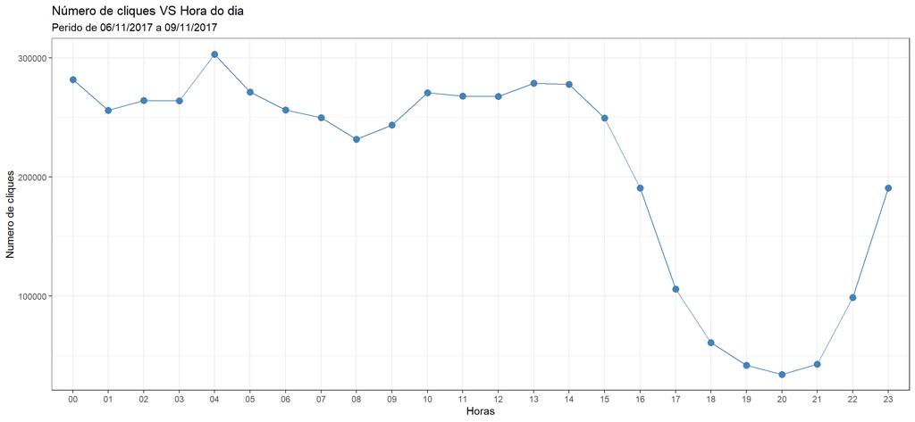

Nesse grafico, pode se observar uma queda consideravel no número de cliques no período da noite, e uma crescente retomada a medida que se aproxima da madrugada.

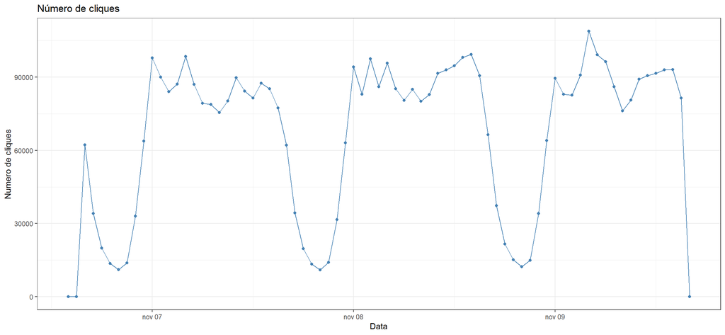

Reproduzindo o mesmo plot mas, dessa vez, como uma série temporal observa-se que existe um padrão no número de cliques. Todos os dias os cliques caem bastante por volta das 16 horas até as 21, quando começam a retomar de novo.

## Features

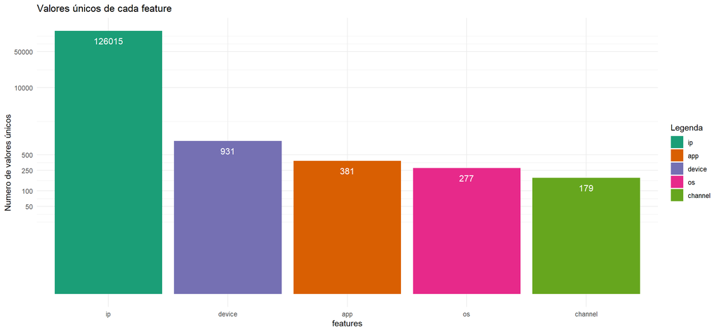

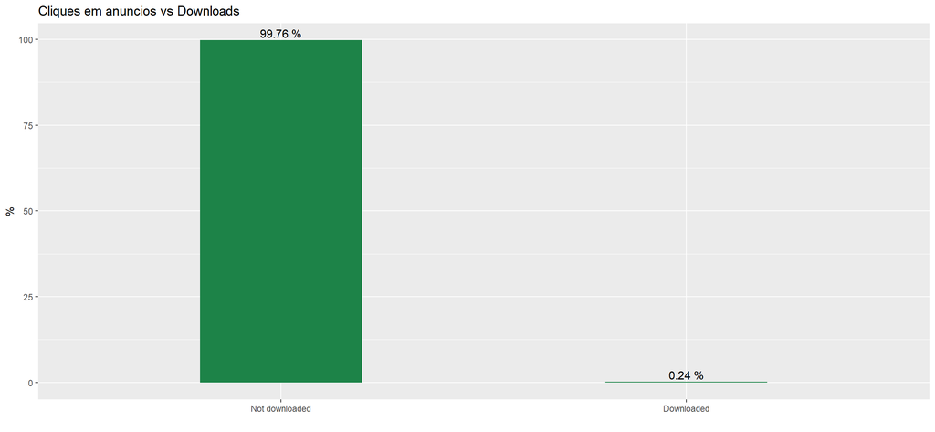

Observa-se que a maioria dos cliques nao geraram o download do aplicativo! Dentre 5 milhões de cliques, menos de 15 mil fizeram o download.

Como essa é a variável target, isso pode ser um problema na hora da construção do modelo de predição, visto que os dados estão muito desbalanceados. Provavelmente será nescessário aplicar uma técnica de balanceamento.

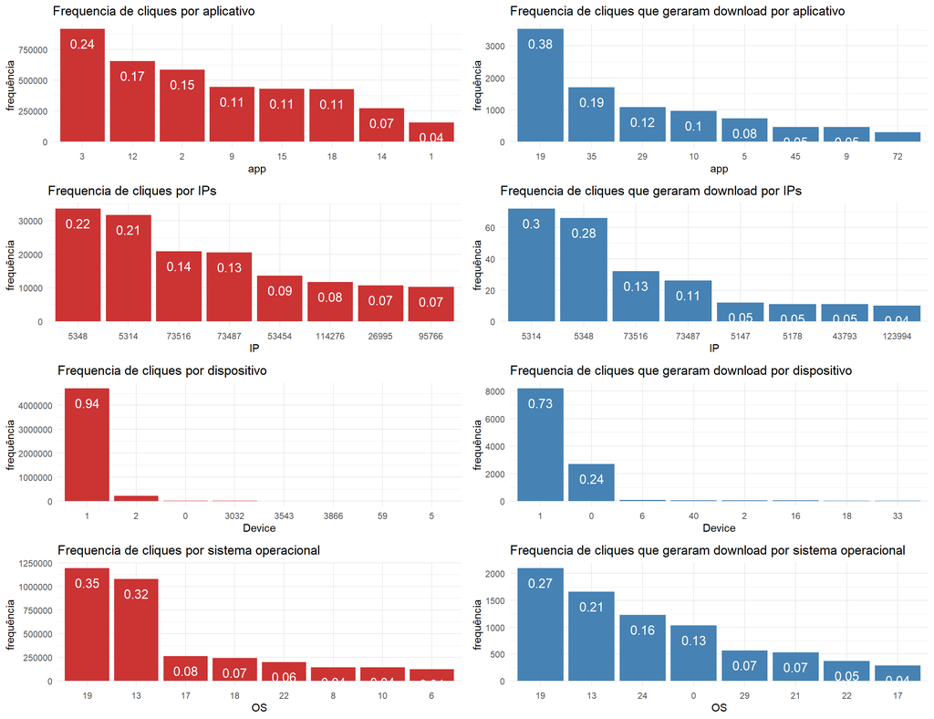

Plot dos valores mais recorrentes de cada variavel.

Além disso, vale ressaltar que apenas um dispositivo é responsável por aproximadamente 94% dos cliques. Lembrando que a feature ‘device’ representa o id de algum dispositivo, ex:(iphone 6, galaxy S8…)

Quando filtramos para apenas cliques que geraram download (gráficos a direita), temos alguns resultados diferentes.

Talvez pudéssemos associar o alto número de cliques mal distribuídos em apenas poucos IPs com o uso de bots. Porem, esses IPs tbm apresentam o maior numero de downloads, como se verifica no gráfico de Ips a direita. Talvez sejam de internets com diversos dispositivos conectados.

Vale ressaltar, também, a diferença dos valores do SO de um grafico para outro.

```
##    Min. 1st Qu.  Median    Mean 3rd Qu.    Max.
##     0.0    54.0   283.5  5301.4  4766.8 85652.0
```

## Criando o modelo

Primeiramente, será necessário balancear os dados, visto que mais de 99% das observações pertencem a somente uma classe. Isso sera feito excluindo aleatoriamente observações da classe majoritaria e preservando todas as observações da classe minoritária.

Serão selecionadas aleatoriamente duzentas mil entre cinco milhões de observações da classe majoritária.

```r
notDownloaded_index <- which(data$is_attributed == 0)
downloaded_index <- which(data$is_attributed == 1)


n_samp_notDownloaded <- 200000
n_samp_downloaded <- min(length(notDownloaded_index),
                         length(downloaded_index))

pick_notDownloaded <- sample(notDownloaded_index, n_samp_notDownloaded)
pick_downloaded <- sample(downloaded_index, n_samp_downloaded)

new_data <- data[c(pick_notDownloaded, pick_downloaded),]
```

Dividindo os dados em dados de treino e dados de teste na proporção de 70% dados de treino e 30% dados de teste.

```r
amostra <- sample.split(new_data$is_attributed, SplitRatio = 0.70)
train <- subset(new_data, amostra == TRUE)
test <- subset(new_data, amostra == FALSE)
```

Utilizando o Random Forest com os valores default

```r
rf_default <- randomForest(is_attributed ~ .,
                           data = train[,-7])
```

Avaliando o modelo com os dados de teste

```r
rf_default.predict <- predict(rf_default, test[,-7])
confusionMatrix(table(rf_default.predict,test$is_attributed), positive = '0')
```

```
## Confusion Matrix and Statistics
##
##
## rf_default.predict     0     1
##                  0 59588   823
##                  1   412  2829
##
##                Accuracy : 0.9806
##                  95% CI : (0.9795, 0.9817)
##     No Information Rate : 0.9426
##     P-Value [Acc > NIR] : < 0.00000000000000022
##
##                   Kappa : 0.8106
##
##  Mcnemar's Test P-Value : < 0.00000000000000022
##
##             Sensitivity : 0.9931
##             Specificity : 0.7746
##          Pos Pred Value : 0.9864
##          Neg Pred Value : 0.8729
##              Prevalence : 0.9426
##          Detection Rate : 0.9362
##    Detection Prevalence : 0.9491
##       Balanced Accuracy : 0.8839
##
##        'Positive' Class : 0
##
```

Para a classe majoritária, a acurácia foi de aproximadamente 0.99 (sensitivity)

Curva ROC e AUC

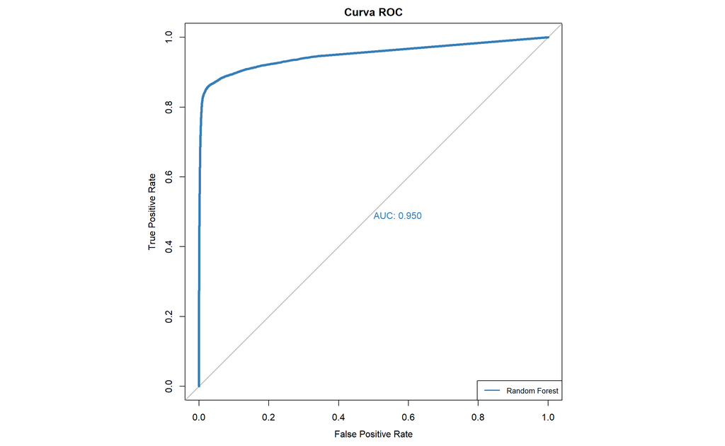